# R Notebook

### Importation du package R:

```r
library(mvtnorm)
```

## RCT(Randomized control trial):

On s’intéresse dans cette partie à la création d’un RCT.

On définit les paramètres, qu’on utilisera dans cette approche.

```r
#Parametres
N=1000
p=4                        #Le nombre de variables confondantes
mu=rep(120,p)              #moyenne pour chaque vecteur de variable confondante
sigma=diag(30,p)           #écart-type pour chaque vecteur de variable confondante
s=c(0.2,0.7,-1,0.3)        #coefficients de chaque variable confondante dans la regression
s0<- 90                    #constante de la régression
To=10                      #paramètre a estimer, effet du traitement
```

Dans cette partie, on génére une base de donnée composée de $50 \times N$ individu, qu’on étudie sur la base des covariables générées: On notera $X=(X_1, X_2, X_3, X_4)$ les quatre variables confondantes, telle:
$$\forall i
\ge 0, X_i \sim \mathcal{N}(\mu,\xi)$$
Afin de simplifier, on optera ici: $\forall i=1..4, \mu_i=120$ et $\xi_i=30$ On note la variable binaire T, le traitement dont on tente d’estimer l’effet sur les individus. Dans un RCT, l’attribution du traitement est indépendante de $X_i, i=1..4$. On générera ainsi un vecteur T telle que $T\sim \mathcal{B}(1,\frac{1}{2})$. Pour de raison de simplification, on opte également pour un outcome $Y$, telle que:
$$Y=X \times \beta+ \tau \times T$$
Autrement dit $\forall j, Y_j=\beta_0+\beta_1 \times X_j1+\beta_2 \times X_j2+ \beta_3 \times X_j3 + \beta_4 \times X_j4 + \tau \times T_j + \xi_j$

```r
#création des covariables
covariates<-rmvnorm(n=50*N,mu,sigma) #création de covariables qui suivent la loi normale.
DF<-as.data.frame(covariates)
names(DF)<-paste("X",1:p,sep="") #on nommera les covariables Xi.
covariates_names <-names(DF)
T<-sample(c(0, 1), size = 50*N, replace = TRUE, prob = c(0.5, 0.5))
DF$T<-T
err<- rnorm(50*N, mean = 0, sd = sqrt(0.002))
eta <- as.vector(covariates%*%s+To*T+s0+err)
DF$Y<-eta
#repartition par groupe de traitement et de control
control_group<-subset(DF$Y, DF$T == 0)
treatment_group<-subset(DF$Y,DF$T==1)
```

### Estimation de l’effet du traitement:

On définit:

- Le groupe de traitement: Le groupe des individus qui ont reçu un traitement (T=1).
- Le groupe de contrôle: Le groupe des individus qui n’ont pas reçu de traitement (T=0).

```r
# Analyse statistique des estimations
treatment_mean_est <- mean(treatment_group)
control_mean_est <- mean(control_group)
```

On veut à partir de l’RCT, trouver l’effet du traitement, on s’intéresse alors au calcul de:
$$\mathbb{E}(Y(1)-Y(0))$$
Il s’agit d’une quantité causale, non observable. Etant donnée que dans un RCT, il y’a pas de correlation entre $T$ et $X_i, \forall i \ge0$. Ainsi, on peut estimer la quantité précédante par $\mathbb{E}(Y|T=1)-\mathbb{E}(Y|T=0)$.

En effet,
$$\mathbb{E}(Y(1)-Y(0))=
\mathbb{E}(Y(1)|T=1)-\mathbb{E}(Y(0)|T=0)$$
$$=\mathbb{E}(Y|T=1)-\mathbb{E}(Y|T=0)$$

```r
effet_treat=treatment_mean_est - control_mean_est
effet_treat
```

```
## [1] 9.881282
```

On veut tester cet estimateur $\hat{\tau}_{DM}$ par un test de student le comparant à la constante définie To:

```r
result<-t.test(treatment_group-control_group,y=NULL,mu = To,var.equal =FALSE)
result
```

```
##
##  One Sample t-test
##
## data:  treatment_group - control_group
## t = -1.9274, df = 25045, p-value = 0.05395
## alternative hypothesis: true mean is not equal to 10
## 95 percent confidence interval:
##   9.759476 10.002024
## sample estimates:
## mean of x
##   9.88075
```

```r
df <- result$parameter
tobs <- result$statistic
alpha <- 0.05
critical_value <- qt(1 - alpha/2, df)
if (abs(tobs) > critical_value) {
  cat("Le test est significatif.\n")
} else {
  cat("Le test n'est pas significatif.\n")
}
```

```
## Le test n'est pas significatif.
```

On veut refaire la simulation, 1000 fois pour estimer le biais de l’estimateur mais encore l’efficacité du test:

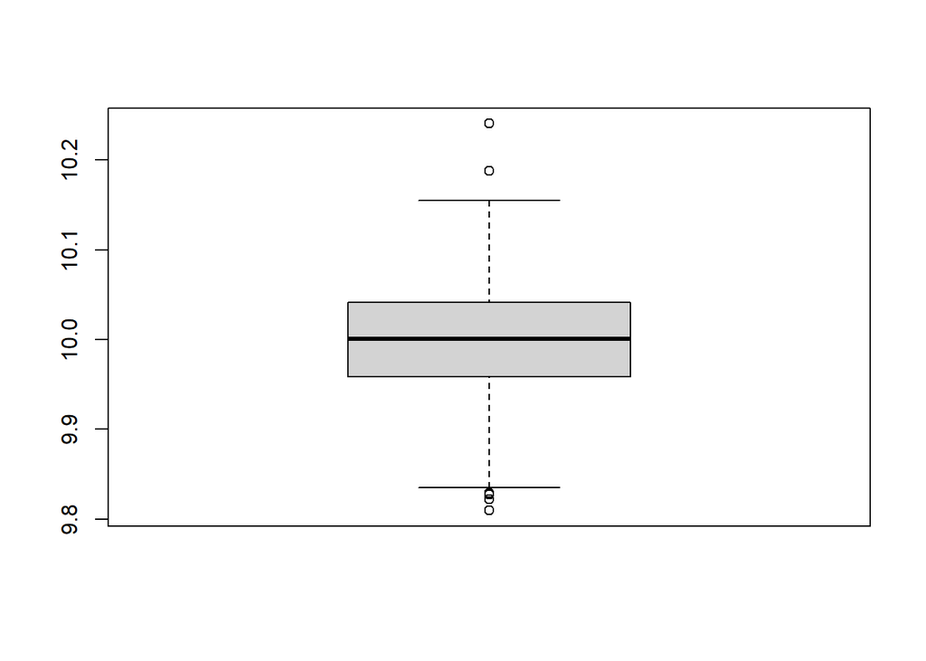

```r
vecteur <- vector("numeric", length = 0)
sum=0

for (i in 1:1000)
{
  covariates<-rmvnorm(n=50*N,mu,sigma) #création de covariables qui suivent la loi normale.
  DF<-as.data.frame(covariates)
  names(DF)<-paste("X",1:p,sep="") #on nommera les covariables Xi.
  covariates_names <-names(DF)
  T<-sample(c(0, 1), size = 50*N, replace = TRUE, prob = c(0.5, 0.5))
  DF$T<-T
  err<- rnorm(50*N, mean = 0, sd = sqrt(0.002))
  eta <- as.vector(covariates%*%s+To*T+s0+err)
  DF$Y<-eta
  #repartition par groupe de traitement et de control
  control_group<-subset(DF$Y, DF$T == 0)
  treatment_group<-subset(DF$Y,DF$T==1)
  treatment_mean_est <- mean(treatment_group)
  control_mean_est <- mean(control_group)
  vecteur[i]=treatment_mean_est-control_mean_est
  suppressWarnings({
  result <- t.test(treatment_group-control_group, y = NULL, mu = To, var.equal = FALSE)
  })
  if(result$p.value<0.05)
  {
    sum<-sum+1
  }
}
boxplot(vecteur)
```

On pourra calculer le pourcentage d’efficacité sur les 1000 simulations:

```r
sum/10
```

```
## [1] 5.1
```

## Observational Data:

### OLS estimator-Regression adjustment-Gformula

On définit les paramètres suivants:

```r
#parameter
Nt=150
Nc=133
meanX_ageT<-65
sd_XT <- 5
meanX_ageC <-20
sd_XC <-5
To<-10
alpha<-15
```

On génère les deux vecteurs $X_t$ et $X_c$ aléatoirement, telle que:
$$X_t:= X|T=1 \sim \mathcal{N}(m_{X_T},
\xi_{X_T})$$
et
$$X_c=X|T=0 \sim
\mathcal{N}(m_{X_C}, \xi_{X_C})$$

```r
Xt<-rnorm(Nt, meanX_ageT, sd_XT)
Xc<-rnorm(Nc, meanX_ageC, sd_XC)
```

On définit le vecteur outcome $Y$, tel que:
$$Y = T\times \to + \alpha \times X
+ \xi$$
Où: $X$ est l’unique variable confondante pour laquelle on opte pour ce problème qui se décompose en $X_t$ et $X_c$. $\xi$ est l’erreur avec $\xi \sim \mathcal{N}(0,\sigma^{2})$.

```r
errT<-rnorm(Nt, mean = 0, sd = sqrt(1))
errc<-rnorm(Nc, mean = 0, sd = sqrt(1))
Yt<-To+alpha*Xt+errT
Yc<-alpha*Xc+errc
X<-c(Xt,Xc)
```

On trace sur le même graphe $Y_t=Y|T=1$ en fonction de $X_t$ et $Y_c=Y|T=0$ en fonction de $X_c$.

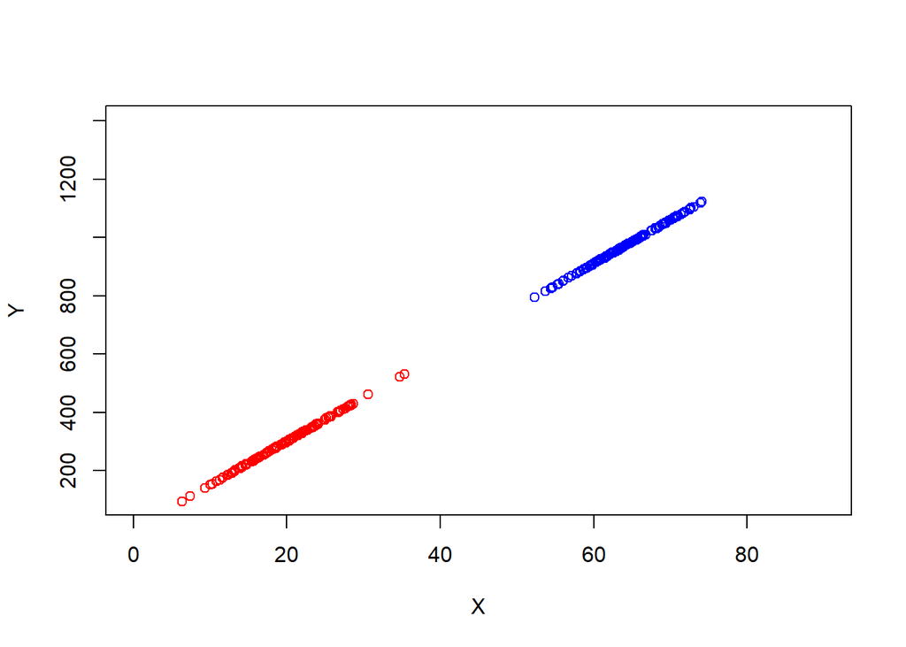

```r
#Tracer le premier graphique
plot(Xt, Yt,type = "p", col = "blue", xlab = "X", ylab = "Y",xlim=c(0,90),ylim=c(100,1400))

#Tracer le second graphique
lines(Xc, Yc,type = "p", col = "red")
```

On tente ensuite de faire une régression linéaire du vecteur $Y$ en fonction $X_t$ et $X_c$ dans le but d’estimer $\tau$.

```r
#regression lineaire:
res1 <-lm(Yt~Xt)
res2 <-lm(Yc~Xc)
```

```r
Y_est1 <- as.matrix(cbind(res1$fitted.values))
Y_est2 <- as.matrix(cbind(res2$fitted.values))
theta.est1 <- res1$coefficients
theta.est2 <- res2$coefficients
```

On définit un vecteur X:

```r
Nx=1000
X<-seq(from = 0, to = 85, length.out = Nx)
```

On tente d’estimer à travers X, la valeur de $\tau$ qu’on appellera $\hat{\tau}$.

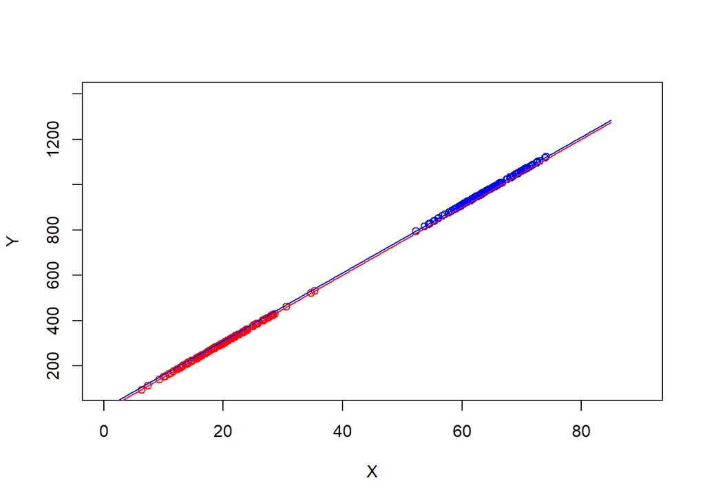

```r
#Tracer le premier graphique
plot(Xt, Yt,type = "p", col = "blue", xlab = "X", ylab = "Y",xlim=c(0,90),ylim=c(100,1400))
#Tracer le second graphique
lines(Xc, Yc,type = "p", col = "red")
lines(X,theta.est1[2]*X+theta.est1[1],type="l",col="blue")
lines(X,theta.est2[2]*X+theta.est2[1],type="l",col="red")
```

Par la formule de $\hat{\tau}_{OLS}$:
$$\hat{\tau}_{OLS}=\frac{1}{n}\sum_{i=1}^{n}(\hat{c}_{(1)}+X_i\hat{b}_{(1)})-(\hat{c}_{(0)}+X_i\hat{b}_{(0)})$$

```r
tau<-theta.est1[1]+1/1000*sum(theta.est1[2]*X)-theta.est2[1]-1/1000*sum(theta.est2[2]*X)
tau
```

```
## (Intercept)
##     10.2374
```

## PSW

Cette méthode consiste à repondérer les Outcomes de sorte à modifier la distribution afin qu’elle soit similaire à la distribution d’une RCT. La méthode est nommée Inverse-propensity weighting après le Propensity score qui s’écrit de la façon suivante:
$$e(X):=\mathbb{P}(W_i|X_i=x) \forall x\in \mathcal{X}$$
Sous l’hypothèse d’unconfoundedness ($\left\{Y_i(1),Y_i(0)\right\}\bot W_i|e(X_i)$) on aura que :

$\tau=\mathbb{E}[Y_i(1)-Y_i(0)$

$=\mathbb{E}[\mathbb{E}[Y_i(1)|X_i]-\mathbb{E}Y_i(0)|X_i]]$

$=\mathbb{E}[\frac{\mathbb{E}[W_i|X_i] \mathbb{E}[Y_i(1)|X_i]}{e(X_i)}-\frac{\mathbb{E}[(1-w_i)Y_i(0)|X_i]}{1-e(X_i)}]$ $=\mathbb{E}[\frac{\mathbb{E}[W_i Y_i|X_i]}{e(X_i)}-\frac{\mathbb{E[(1-W_i)Y_i(0)|X_i]}}{1-e(X_i)}]$

$=\mathbb{E}[\frac{ W_i Y_i}{e(X_i)}-\frac{(1-W_i)Y_i}{1-e(X_i)}]$

D’où l’estimateur s’écrit:
$$\hat{\tau}_{IPW}=\frac{1}{n}\sum_{i=1}^{n}(\frac{W_i
Yw_i}{e(X_i)}-\frac{(1-W_i)Y_i}{1-e(X_i)})$$

```r
compute_ipw <- function(DF, normalized = FALSE){

  n <- nrow(DF[DF$T ==1, ])
  m <- nrow(DF[DF$T ==0, ])


  # Estimation of P(T = 1 | X)
  # p <-- P(T = 1 | X)
  temp <- DF
  #with logistic regression
    p.fit  <- glm(temp$T ~., family = binomial("logit"), data = temp[, !names(temp) %in% c("T", "Y")])
    p <- predict(p.fit, type = "response", newdata = temp) ###

  # Store odds
  temp$odds <-p

  # Keep only RCT for the rest of the calculus

  if (normalized == FALSE){
    tau_ipw <- (2/m)*with(temp,(1/(50*N))*sum(T*Y/odds - (1-T)*Y/(1-odds)))
  } else {
    tau_ipw <- with(temp, (1/(50*N))*sum(T*Y/odds - (1-T)*Y/(1-odds)))
  }

  return(tau_ipw)
}
```

```r
compute_ipw(DF)
```

```
## [1] 0.0007992623
```